# Overview

Dataset info

| Number of variables | 42 |
| --- | --- |
| Number of observations | 14800 |
| Total Missing (%) | 0.0% |
| Total size in memory | 4.7 MiB |
| Average record size in memory | 336.0 B |

Variables types

| Numeric | 13 |
| --- | --- |
| Categorical | 27 |
| Date | 0 |
| Text (Unique) | 0 |
| Rejected | 2 |

Warnings

- `ADTIND` has 4417 / 29.8% zeros
- `ADTOCC` has 4417 / 29.8% zeros
- `AHRSPAY` has 14053 / 95.0% zeros
- `AWKSTAT` has constant value ChildrenorArmedForces Rejected
- `CAPGAIN` has 13160 / 88.9% zeros
- `CAPLOSS` has 13945 / 94.2% zeros
- `DIVVAL` has 10978 / 74.2% zeros
- `NOEMP` has 4031 / 27.2% zeros
- `SEOTR` has 13032 / 88.1% zeros
- `VETQVA` has 1869 / 12.6% zeros
- `VETYN` has 4031 / 27.2% zeros
- `WKSWORK` has constant value 94 Rejected

# Variables

AAGE  
Numeric

| Distinct count | 91 |
| --- | --- |
| Unique (%) | 0.6% |
| Missing (%) | 0.0% |
| Missing (n) | 0 |
| Infinite (%) | 0.0% |
| Infinite (n) | 0 |

| Mean | 39.779 |
| --- | --- |
| Minimum | 0 |
| Maximum | 90 |
| Zeros (%) | 0.8% |

Toggle details

Quantile statistics

| Minimum | 0 |
| --- | --- |
| 5-th percentile | 5 |
| Q1 | 29 |
| Median | 41 |
| Q3 | 51 |
| 95-th percentile | 72 |
| Maximum | 90 |
| Range | 90 |
| Interquartile range | 22 |

Descriptive statistics

| Standard deviation | 18.879 |
| --- | --- |
| Coef of variation | 0.47461 |
| Kurtosis | -0.2295 |
| Mean | 39.779 |
| MAD | 14.767 |
| Skewness | -0.049407 |
| Sum | 588722 |
| Variance | 356.43 |
| Memory size | 115.7 KiB |

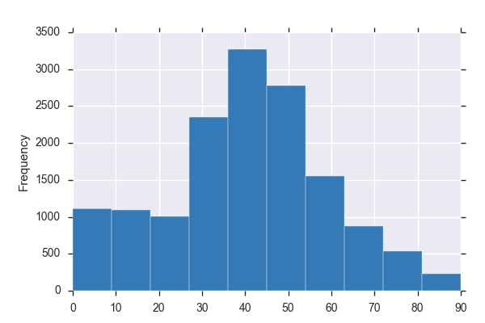

ACLSWKR  
Categorical

| Distinct count | 9 |
| --- | --- |
| Unique (%) | 0.1% |
| Missing (%) | 0.0% |
| Missing (n) | 0 |

| Private | 6968 |
| --- | --- |
| Not_in_universe | 4395 |
| Self-employed-notIncorporated | 1005 |
| Other values (6) | 2432 |

Toggle details

| Value | Count | Frequency (%) |  |
| --- | --- | --- | --- |
| Private | 6968 | 47.1% |  |
| Not_in_universe | 4395 | 29.7% |  |
| Self-employed-notIncorporated | 1005 | 6.8% |  |
| LocalGovernment | 769 | 5.2% |  |
| Self-employed-incorporated | 758 | 5.1% |  |
| StateGovernment | 448 | 3.0% |  |
| FederalGovernment | 428 | 2.9% |  |
| NeverWorked | 22 | 0.1% |  |
| WithoutPay | 7 | 0.0% |  |

ADTIND  
Numeric

| Distinct count | 51 |
| --- | --- |
| Unique (%) | 0.3% |
| Missing (%) | 0.0% |
| Missing (n) | 0 |
| Infinite (%) | 0.0% |
| Infinite (n) | 0 |

| Mean | 21.621 |
| --- | --- |
| Minimum | 0 |
| Maximum | 51 |
| Zeros (%) | 29.8% |

Toggle details

Quantile statistics

| Minimum | 0 |
| --- | --- |
| 5-th percentile | 0 |
| Q1 | 0 |
| Median | 29 |
| Q3 | 37 |
| 95-th percentile | 45 |
| Maximum | 51 |
| Range | 51 |
| Interquartile range | 37 |

Descriptive statistics

| Standard deviation | 18.048 |
| --- | --- |
| Coef of variation | 0.83476 |
| Kurtosis | -1.6571 |
| Mean | 21.621 |
| MAD | 16.915 |
| Skewness | -0.057834 |
| Sum | 319993 |
| Variance | 325.75 |
| Memory size | 115.7 KiB |

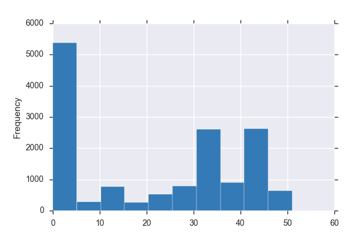

ADTOCC  
Numeric

| Distinct count | 47 |
| --- | --- |
| Unique (%) | 0.3% |
| Missing (%) | 0.0% |
| Missing (n) | 0 |
| Infinite (%) | 0.0% |
| Infinite (n) | 0 |

| Mean | 11.965 |
| --- | --- |
| Minimum | 0 |
| Maximum | 46 |
| Zeros (%) | 29.8% |

Toggle details

Quantile statistics

| Minimum | 0 |
| --- | --- |
| 5-th percentile | 0 |
| Q1 | 0 |
| Median | 5 |
| Q3 | 23 |
| 95-th percentile | 38 |
| Maximum | 46 |
| Range | 46 |
| Interquartile range | 23 |

Descriptive statistics

| Standard deviation | 13.524 |
| --- | --- |
| Coef of variation | 1.1303 |
| Kurtosis | -0.70003 |
| Mean | 11.965 |
| MAD | 11.666 |
| Skewness | 0.84933 |
| Sum | 177089 |
| Variance | 182.91 |
| Memory size | 115.7 KiB |

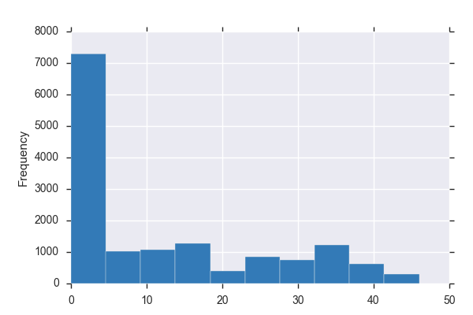

AHGA  
Categorical

| Distinct count | 17 |
| --- | --- |
| Unique (%) | 0.1% |
| Missing (%) | 0.0% |
| Missing (n) | 0 |

| Highschoolgraduate | 2995 |
| --- | --- |
| Bachelorsdegree(BAABBS) | 2958 |
| Somecollegebutnodegree | 2113 |
| Other values (14) | 6734 |

Toggle details

| Value | Count | Frequency (%) |  |
| --- | --- | --- | --- |
| Highschoolgraduate | 2995 | 20.2% |  |
| Bachelorsdegree(BAABBS) | 2958 | 20.0% |  |
| Somecollegebutnodegree | 2113 | 14.3% |  |
| Children | 1869 | 12.6% |  |
| Mastersdegree(MAMSMEngMEdMSWMBA) | 1361 | 9.2% |  |
| Profschooldegree(MDDDSDVMLLBJD) | 617 | 4.2% |  |
| Associatesdegree-occup/vocational | 457 | 3.1% |  |
| Doctoratedegree(PhDEdD) | 389 | 2.6% |  |
| Associatesdegree-academicprogram | 377 | 2.5% |  |
| 10thgrade | 361 | 2.4% |  |
| 7thand8thgrade | 353 | 2.4% |  |
| 11thgrade | 305 | 2.1% |  |
| 9thgrade | 265 | 1.8% |  |
| 5thor6thgrade | 142 | 1.0% |  |
| 12thgradenodiploma | 114 | 0.8% |  |
| First2nd3rdor4thgrade | 88 | 0.6% |  |
| Lessthan1stgrade | 36 | 0.2% |  |

AHRSPAY  
Numeric

| Distinct count | 271 |
| --- | --- |
| Unique (%) | 1.8% |
| Missing (%) | 0.0% |
| Missing (n) | 0 |
| Infinite (%) | 0.0% |
| Infinite (n) | 0 |

| Mean | 65 |
| --- | --- |
| Minimum | 0 |
| Maximum | 9999 |
| Zeros (%) | 95.0% |

Toggle details

Quantile statistics

| Minimum | 0 |
| --- | --- |
| 5-th percentile | 0 |
| Q1 | 0 |
| Median | 0 |
| Q3 | 0 |
| 95-th percentile | 400 |
| Maximum | 9999 |
| Range | 9999 |
| Interquartile range | 0 |

Descriptive statistics

| Standard deviation | 349.47 |
| --- | --- |
| Coef of variation | 5.3764 |
| Kurtosis | 146.23 |
| Mean | 65 |
| MAD | 123.44 |
| Skewness | 9.1337 |
| Sum | 961997 |
| Variance | 122130 |
| Memory size | 115.7 KiB |

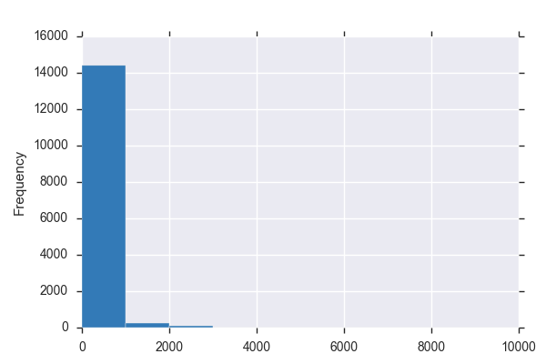

AHSCOL  
Categorical

| Distinct count | 3 |
| --- | --- |
| Unique (%) | 0.0% |
| Missing (%) | 0.0% |
| Missing (n) | 0 |

| Not_in_universe | 14301 |
| --- | --- |
| Highschool | 261 |
| Collegeoruniversity | 238 |

Toggle details

| Value | Count | Frequency (%) |  |
| --- | --- | --- | --- |
| Not_in_universe | 14301 | 96.6% |  |
| Highschool | 261 | 1.8% |  |
| Collegeoruniversity | 238 | 1.6% |  |

AMARITL  
Categorical

| Distinct count | 7 |
| --- | --- |
| Unique (%) | 0.0% |
| Missing (%) | 0.0% |
| Missing (n) | 0 |

| Married-civilianspousepresent | 8714 |
| --- | --- |
| Nevermarried | 3990 |
| Divorced | 1098 |
| Other values (4) | 998 |

Toggle details

| Value | Count | Frequency (%) |  |
| --- | --- | --- | --- |
| Married-civilianspousepresent | 8714 | 58.9% |  |
| Nevermarried | 3990 | 27.0% |  |
| Divorced | 1098 | 7.4% |  |
| Widowed | 632 | 4.3% |  |
| Separated | 216 | 1.5% |  |
| Married-spouseabsent | 106 | 0.7% |  |
| Married-AFspousepresent | 44 | 0.3% |  |

AMJIND  
Categorical

| Distinct count | 24 |
| --- | --- |
| Unique (%) | 0.2% |
| Missing (%) | 0.0% |
| Missing (n) | 0 |

| Not_in_universeorchildren | 4417 |
| --- | --- |
| Manufacturing-durablegoods | 1233 |
| Retailtrade | 1088 |
| Other values (21) | 8062 |

Toggle details

| Value | Count | Frequency (%) |  |
| --- | --- | --- | --- |
| Not_in_universeorchildren | 4417 | 29.8% |  |
| Manufacturing-durablegoods | 1233 | 8.3% |  |
| Retailtrade | 1088 | 7.4% |  |
| Financeinsuranceandrealestate | 882 | 6.0% |  |
| Education | 807 | 5.5% |  |
| Manufacturing-nondurablegoods | 770 | 5.2% |  |
| Otherprofessionalservices | 716 | 4.8% |  |
| Publicadministration | 597 | 4.0% |  |
| Businessandrepairservices | 577 | 3.9% |  |
| Construction | 566 | 3.8% |  |
| Medicalexcepthospital | 528 | 3.6% |  |
| Transportation | 478 | 3.2% |  |
| Wholesaletrade | 439 | 3.0% |  |
| Hospitalservices | 419 | 2.8% |  |
| Agriculture | 238 | 1.6% |  |
| Communications | 211 | 1.4% |  |
| Utilitiesandsanitaryservices | 199 | 1.3% |  |
| Socialservices | 156 | 1.1% |  |
| PersonalservicesexceptprivateHH | 152 | 1.0% |  |
| Entertainment | 132 | 0.9% |  |
| Other values (4) | 195 | 1.3% |  |

AMJOCC  
Categorical

| Distinct count | 15 |
| --- | --- |
| Unique (%) | 0.1% |
| Missing (%) | 0.0% |
| Missing (n) | 0 |

| Not_in_universe | 4417 |
| --- | --- |
| Executiveadminandmanagerial | 2453 |
| Professionalspecialty | 2450 |
| Other values (12) | 5480 |

Toggle details

| Value | Count | Frequency (%) |  |
| --- | --- | --- | --- |
| Not_in_universe | 4417 | 29.8% |  |
| Executiveadminandmanagerial | 2453 | 16.6% |  |
| Professionalspecialty | 2450 | 16.6% |  |
| Sales | 1350 | 9.1% |  |
| Precisionproductioncraft&repair | 969 | 6.5% |  |
| Admsupportincludingclerical | 905 | 6.1% |  |
| Otherservice | 529 | 3.6% |  |
| Machineoperatorsassmblrs&inspctrs | 388 | 2.6% |  |
| Transportationandmaterialmoving | 359 | 2.4% |  |
| Techniciansandrelatedsupport | 302 | 2.0% |  |
| Farmingforestryandfishing | 223 | 1.5% |  |
| Protectiveservices | 212 | 1.4% |  |
| Handlersequipcleanersetc | 203 | 1.4% |  |
| Privatehouseholdservices | 34 | 0.2% |  |
| ArmedForces | 6 | 0.0% |  |

ARACE  
Categorical

| Distinct count | 5 |
| --- | --- |
| Unique (%) | 0.0% |
| Missing (%) | 0.0% |
| Missing (n) | 0 |

| White | 13068 |
| --- | --- |
| Black | 1087 |
| AsianorPacificIslander | 377 |
| Other values (2) | 268 |

Toggle details

| Value | Count | Frequency (%) |  |
| --- | --- | --- | --- |
| White | 13068 | 88.3% |  |
| Black | 1087 | 7.3% |  |
| AsianorPacificIslander | 377 | 2.5% |  |
| Other | 145 | 1.0% |  |
| AmerIndianAleutorEskimo | 123 | 0.8% |  |

AREORGN  
Categorical

| Distinct count | 9 |
| --- | --- |
| Unique (%) | 0.1% |
| Missing (%) | 0.0% |
| Missing (n) | 0 |

| Allother | 13479 |
| --- | --- |
| Mexican-American | 439 |
| Mexican(Mexicano) | 320 |
| Other values (6) | 562 |

Toggle details

| Value | Count | Frequency (%) |  |
| --- | --- | --- | --- |
| Allother | 13479 | 91.1% |  |
| Mexican-American | 439 | 3.0% |  |
| Mexican(Mexicano) | 320 | 2.2% |  |
| PuertoRican | 161 | 1.1% |  |
| CentralorSouthAmerican | 156 | 1.1% |  |
| OtherSpanish | 125 | 0.8% |  |
| Cuban | 77 | 0.5% |  |
| Donotknow | 23 | 0.2% |  |
| Chicano | 20 | 0.1% |  |

ASEX  
Categorical

| Distinct count | 2 |
| --- | --- |
| Unique (%) | 0.0% |
| Missing (%) | 0.0% |
| Missing (n) | 0 |

| Male | 9288 |
| --- | --- |
| Female | 5512 |

Toggle details

| Value | Count | Frequency (%) |  |
| --- | --- | --- | --- |
| Male | 9288 | 62.8% |  |
| Female | 5512 | 37.2% |  |

AUNMEM  
Categorical

| Distinct count | 3 |
| --- | --- |
| Unique (%) | 0.0% |
| Missing (%) | 0.0% |
| Missing (n) | 0 |

| Not_in_universe | 12826 |
| --- | --- |
| No | 1621 |
| Yes | 353 |

Toggle details

| Value | Count | Frequency (%) |  |
| --- | --- | --- | --- |
| Not_in_universe | 12826 | 86.7% |  |
| No | 1621 | 11.0% |  |
| Yes | 353 | 2.4% |  |

AUNTYPE  
Categorical

| Distinct count | 6 |
| --- | --- |
| Unique (%) | 0.0% |
| Missing (%) | 0.0% |
| Missing (n) | 0 |

| Not_in_universe | 14450 |
| --- | --- |
| Otherjobloser | 152 |
| Re-entrant | 103 |
| Other values (3) | 95 |

Toggle details

| Value | Count | Frequency (%) |  |
| --- | --- | --- | --- |
| Not_in_universe | 14450 | 97.6% |  |
| Otherjobloser | 152 | 1.0% |  |
| Re-entrant | 103 | 0.7% |  |
| Jobloser-onlayoff | 45 | 0.3% |  |
| Jobleaver | 28 | 0.2% |  |
| Newentrant | 22 | 0.1% |  |

Constant

*This variable is constant and should be ignored for analysis*

| Constant value | ChildrenorArmedForces |
| --- | --- |

CAPGAIN  
Numeric

| Distinct count | 91 |
| --- | --- |
| Unique (%) | 0.6% |
| Missing (%) | 0.0% |
| Missing (n) | 0 |
| Infinite (%) | 0.0% |
| Infinite (n) | 0 |

| Mean | 2486.6 |
| --- | --- |
| Minimum | 0 |
| Maximum | 99999 |
| Zeros (%) | 88.9% |

Toggle details

Quantile statistics

| Minimum | 0 |
| --- | --- |
| 5-th percentile | 0 |
| Q1 | 0 |
| Median | 0 |
| Q3 | 0 |
| 95-th percentile | 15024 |
| Maximum | 99999 |
| Range | 99999 |
| Interquartile range | 0 |

Descriptive statistics

| Standard deviation | 12241 |
| --- | --- |
| Coef of variation | 4.9229 |
| Kurtosis | 53.754 |
| Mean | 2486.6 |
| MAD | 4428.5 |
| Skewness | 7.1891 |
| Sum | 36801496 |
| Variance | 149850000 |
| Memory size | 115.7 KiB |

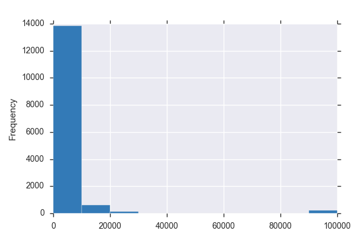

CAPLOSS  
Numeric

| Distinct count | 70 |
| --- | --- |
| Unique (%) | 0.5% |
| Missing (%) | 0.0% |
| Missing (n) | 0 |
| Infinite (%) | 0.0% |
| Infinite (n) | 0 |

| Mean | 115.03 |
| --- | --- |
| Minimum | 0 |
| Maximum | 4356 |
| Zeros (%) | 94.2% |

Toggle details

Quantile statistics

| Minimum | 0 |
| --- | --- |
| 5-th percentile | 0 |
| Q1 | 0 |
| Median | 0 |
| Q3 | 0 |
| 95-th percentile | 1740 |
| Maximum | 4356 |
| Range | 4356 |
| Interquartile range | 0 |

Descriptive statistics

| Standard deviation | 471.17 |
| --- | --- |
| Coef of variation | 4.096 |
| Kurtosis | 14.403 |
| Mean | 115.03 |
| MAD | 216.77 |
| Skewness | 3.9722 |
| Sum | 1702472 |
| Variance | 222000 |
| Memory size | 115.7 KiB |

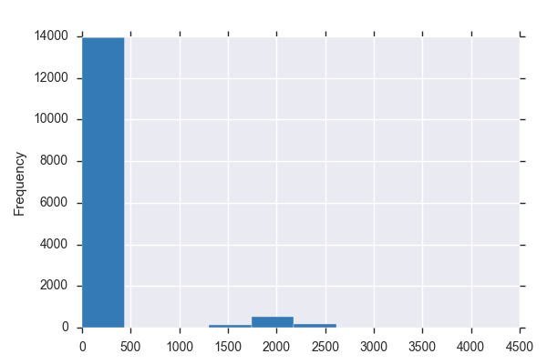

DIVVAL  
Numeric

| Distinct count | 508 |
| --- | --- |
| Unique (%) | 3.4% |
| Missing (%) | 0.0% |
| Missing (n) | 0 |
| Infinite (%) | 0.0% |
| Infinite (n) | 0 |

| Mean | 814.16 |
| --- | --- |
| Minimum | 0 |
| Maximum | 99999 |
| Zeros (%) | 74.2% |

Toggle details

Quantile statistics

| Minimum | 0 |
| --- | --- |
| 5-th percentile | 0 |
| Q1 | 0 |
| Median | 0 |
| Q3 | 5 |
| 95-th percentile | 3000 |
| Maximum | 99999 |
| Range | 99999 |
| Interquartile range | 5 |

Descriptive statistics

| Standard deviation | 4814.7 |
| --- | --- |
| Coef of variation | 5.9138 |
| Kurtosis | 200.09 |
| Mean | 814.16 |
| MAD | 1383.2 |
| Skewness | 12.504 |
| Sum | 12049556 |
| Variance | 23182000 |
| Memory size | 115.7 KiB |

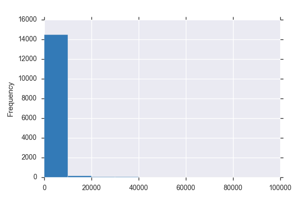

FILESTAT  
Categorical

| Distinct count | 6 |
| --- | --- |
| Unique (%) | 0.0% |
| Missing (%) | 0.0% |
| Missing (n) | 0 |

| Jointbothunder65 | 7735 |
| --- | --- |
| Nonfiler | 2953 |
| Single | 2747 |
| Other values (3) | 1365 |

Toggle details

| Value | Count | Frequency (%) |  |
| --- | --- | --- | --- |
| Jointbothunder65 | 7735 | 52.3% |  |
| Nonfiler | 2953 | 20.0% |  |
| Single | 2747 | 18.6% |  |
| Headofhousehold | 541 | 3.7% |  |
| Jointboth65+ | 511 | 3.5% |  |
| Jointoneunder65&one65+ | 313 | 2.1% |  |

GRINREG  
Categorical

| Distinct count | 6 |
| --- | --- |
| Unique (%) | 0.0% |
| Missing (%) | 0.0% |
| Missing (n) | 0 |

| Not_in_universe | 12928 |
| --- | --- |
| South | 572 |
| West | 500 |
| Other values (3) | 800 |

Toggle details

| Value | Count | Frequency (%) |  |
| --- | --- | --- | --- |
| Not_in_universe | 12928 | 87.4% |  |
| South | 572 | 3.9% |  |
| West | 500 | 3.4% |  |
| Midwest | 417 | 2.8% |  |
| Northeast | 337 | 2.3% |  |
| Abroad | 46 | 0.3% |  |

GRINST  
Categorical

| Distinct count | 50 |
| --- | --- |
| Unique (%) | 0.3% |
| Missing (%) | 0.0% |
| Missing (n) | 0 |

| Not_in_universe | 12928 |
| --- | --- |
| California | 204 |
| NorthCarolina | 131 |
| Other values (47) | 1537 |

Toggle details

| Value | Count | Frequency (%) |  |
| --- | --- | --- | --- |
| Not_in_universe | 12928 | 87.4% |  |
| California | 204 | 1.4% |  |
| NorthCarolina | 131 | 0.9% |  |
| Utah | 124 | 0.8% |  |
| Florida | 121 | 0.8% |  |
| Minnesota | 86 | 0.6% |  |
| Oklahoma | 77 | 0.5% |  |
| NewMexico | 75 | 0.5% |  |
| Abroad | 62 | 0.4% |  |
| Indiana | 57 | 0.4% |  |
| Michigan | 54 | 0.4% |  |
| NorthDakota | 50 | 0.3% |  |
| Alaska | 47 | 0.3% |  |
| NewHampshire | 37 | 0.2% |  |
| Kentucky | 34 | 0.2% |  |
| Texas | 31 | 0.2% |  |
| Colorado | 29 | 0.2% |  |
| Arizona | 28 | 0.2% |  |
| NewYork | 28 | 0.2% |  |
| Maine | 26 | 0.2% |  |
| Other values (30) | 571 | 3.9% |  |

HHDFMX  
Categorical

| Distinct count | 30 |
| --- | --- |
| Unique (%) | 0.2% |
| Missing (%) | 0.0% |
| Missing (n) | 0 |

| Householder | 6669 |
| --- | --- |
| Spouseofhouseholder | 2796 |
| Child<18nevermarrnotinsubfamily | 1990 |
| Other values (27) | 3345 |

Toggle details

| Value | Count | Frequency (%) |  |
| --- | --- | --- | --- |
| Householder | 6669 | 45.1% |  |
| Spouseofhouseholder | 2796 | 18.9% |  |
| Child<18nevermarrnotinsubfamily | 1990 | 13.4% |  |
| Nonfamilyhouseholder | 1861 | 12.6% |  |
| Child18+nevermarrNotinasubfamily | 537 | 3.6% |  |
| Secondaryindividual | 330 | 2.2% |  |
| OtherRel18+evermarrnotinsubfamily | 78 | 0.5% |  |
| OtherRel18+nevermarrnotinsubfamily | 71 | 0.5% |  |
| Grandchild<18nevermarrchildofsubfamilyRP | 66 | 0.4% |  |
| Child18+evermarrNotinasubfamily | 59 | 0.4% |  |
| RPofunrelatedsubfamily | 46 | 0.3% |  |
| Grandchild<18nevermarrnotinsubfamily | 41 | 0.3% |  |
| Child18+evermarrRPofsubfamily | 33 | 0.2% |  |
| OtherRel18+spouseofsubfamilyRP | 33 | 0.2% |  |
| Childunder18ofRPofunrelsubfamily | 33 | 0.2% |  |
| OtherRel18+evermarrRPofsubfamily | 32 | 0.2% |  |
| OtherRel<18nevermarrchildofsubfamilyRP | 26 | 0.2% |  |
| Child18+nevermarrRPofsubfamily | 26 | 0.2% |  |
| OtherRel<18nevermarrnotinsubfamily | 21 | 0.1% |  |
| Grandchild18+nevermarrnotinsubfamily | 18 | 0.1% |  |
| Other values (10) | 34 | 0.2% |  |

HHDREL  
Categorical

| Distinct count | 8 |
| --- | --- |
| Unique (%) | 0.1% |
| Missing (%) | 0.0% |
| Missing (n) | 0 |

| Householder | 8530 |
| --- | --- |
| Spouseofhouseholder | 2797 |
| Childunder18nevermarried | 1993 |
| Other values (5) | 1480 |

Toggle details

| Value | Count | Frequency (%) |  |
| --- | --- | --- | --- |
| Householder | 8530 | 57.6% |  |
| Spouseofhouseholder | 2797 | 18.9% |  |
| Childunder18nevermarried | 1993 | 13.5% |  |
| Child18orolder | 662 | 4.5% |  |
| Nonrelativeofhouseholder | 417 | 2.8% |  |
| Otherrelativeofhouseholder | 396 | 2.7% |  |
| GroupQuarters-Secondaryindividual | 4 | 0.0% |  |
| Childunder18evermarried | 1 | 0.0% |  |

MARSUPWT  
Numeric

| Distinct count | 11390 |
| --- | --- |
| Unique (%) | 77.0% |
| Missing (%) | 0.0% |
| Missing (n) | 0 |
| Infinite (%) | 0.0% |
| Infinite (n) | 0 |

| Mean | 1751.1 |
| --- | --- |
| Minimum | 88.92 |
| Maximum | 13145 |
| Zeros (%) | 0.0% |

Toggle details

Quantile statistics

| Minimum | 88.92 |
| --- | --- |
| 5-th percentile | 388.22 |
| Q1 | 1095.3 |
| Median | 1659.4 |
| Q3 | 2170.2 |
| 95-th percentile | 3510.8 |
| Maximum | 13145 |
| Range | 13056 |
| Interquartile range | 1074.9 |

Descriptive statistics

| Standard deviation | 956.21 |
| --- | --- |
| Coef of variation | 0.54606 |
| Kurtosis | 4.2637 |
| Mean | 1751.1 |
| MAD | 715.48 |
| Skewness | 1.2506 |
| Sum | 25917000 |
| Variance | 914330 |
| Memory size | 115.7 KiB |

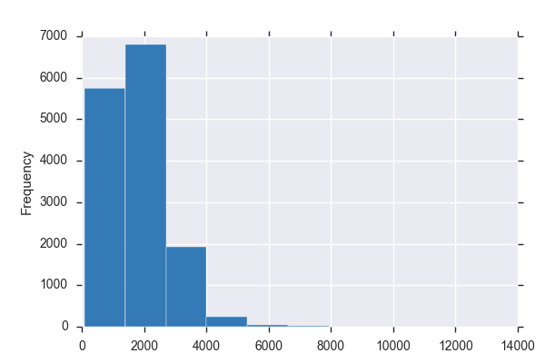

MIGMTR1  
Categorical

| Distinct count | 9 |
| --- | --- |
| Unique (%) | 0.1% |
| Missing (%) | 0.0% |
| Missing (n) | 0 |

| Nonmover | 12816 |
| --- | --- |
| MSAtoMSA | 1351 |
| NonMSAtononMSA | 275 |
| Other values (6) | 358 |

Toggle details

| Value | Count | Frequency (%) |  |
| --- | --- | --- | --- |
| Nonmover | 12816 | 86.6% |  |
| MSAtoMSA | 1351 | 9.1% |  |
| NonMSAtononMSA | 275 | 1.9% |  |
| Not_in_universe | 112 | 0.8% |  |
| MSAtononMSA | 85 | 0.6% |  |
| NonMSAtoMSA | 70 | 0.5% |  |
| Notidentifiable | 45 | 0.3% |  |
| AbroadtoMSA | 38 | 0.3% |  |
| AbroadtononMSA | 8 | 0.1% |  |

MIGMTR3  
Categorical

| Distinct count | 8 |
| --- | --- |
| Unique (%) | 0.1% |
| Missing (%) | 0.0% |
| Missing (n) | 0 |

| Nonmover | 12816 |
| --- | --- |
| Samecounty | 1157 |
| Differentcountysamestate | 337 |
| Other values (5) | 490 |

Toggle details

| Value | Count | Frequency (%) |  |
| --- | --- | --- | --- |
| Nonmover | 12816 | 86.6% |  |
| Samecounty | 1157 | 7.8% |  |
| Differentcountysamestate | 337 | 2.3% |  |
| Differentregion | 158 | 1.1% |  |
| Not_in_universe | 112 | 0.8% |  |
| Differentstatesamedivision | 106 | 0.7% |  |
| Differentdivisionsameregion | 68 | 0.5% |  |
| Abroad | 46 | 0.3% |  |

MIGMTR4  
Categorical

| Distinct count | 9 |
| --- | --- |
| Unique (%) | 0.1% |
| Missing (%) | 0.0% |
| Missing (n) | 0 |

| Nonmover | 12816 |
| --- | --- |
| Samecounty | 1157 |
| Differentcountysamestate | 337 |
| Other values (6) | 490 |

Toggle details

| Value | Count | Frequency (%) |  |
| --- | --- | --- | --- |
| Nonmover | 12816 | 86.6% |  |
| Samecounty | 1157 | 7.8% |  |
| Differentcountysamestate | 337 | 2.3% |  |
| DifferentstateinSouth | 118 | 0.8% |  |
| Not_in_universe | 112 | 0.8% |  |
| DifferentstateinWest | 91 | 0.6% |  |
| DifferentstateinMidwest | 69 | 0.5% |  |
| DifferentstateinNortheast | 54 | 0.4% |  |
| Abroad | 46 | 0.3% |  |

MIGSAME  
Categorical

| Distinct count | 3 |
| --- | --- |
| Unique (%) | 0.0% |
| Missing (%) | 0.0% |
| Missing (n) | 0 |

| Yes | 12816 |
| --- | --- |
| No | 1872 |
| Not_in_universeunder1yearold | 112 |

Toggle details

| Value | Count | Frequency (%) |  |
| --- | --- | --- | --- |
| Yes | 12816 | 86.6% |  |
| No | 1872 | 12.6% |  |
| Not_in_universeunder1yearold | 112 | 0.8% |  |

MIGSUN  
Categorical

| Distinct count | 3 |
| --- | --- |
| Unique (%) | 0.0% |
| Missing (%) | 0.0% |
| Missing (n) | 0 |

| Not_in_universe | 12928 |
| --- | --- |
| No | 1171 |
| Yes | 701 |

Toggle details

| Value | Count | Frequency (%) |  |
| --- | --- | --- | --- |
| Not_in_universe | 12928 | 87.4% |  |
| No | 1171 | 7.9% |  |
| Yes | 701 | 4.7% |  |

NOEMP  
Numeric

| Distinct count | 7 |
| --- | --- |
| Unique (%) | 0.0% |
| Missing (%) | 0.0% |
| Missing (n) | 0 |
| Infinite (%) | 0.0% |
| Infinite (n) | 0 |

| Mean | 2.8701 |
| --- | --- |
| Minimum | 0 |
| Maximum | 6 |
| Zeros (%) | 27.2% |

Toggle details

Quantile statistics

| Minimum | 0 |
| --- | --- |
| 5-th percentile | 0 |
| Q1 | 0 |
| Median | 3 |
| Q3 | 6 |
| 95-th percentile | 6 |
| Maximum | 6 |
| Range | 6 |
| Interquartile range | 6 |

Descriptive statistics

| Standard deviation | 2.4456 |
| --- | --- |
| Coef of variation | 0.85212 |
| Kurtosis | -1.6234 |
| Mean | 2.8701 |
| MAD | 2.2384 |
| Skewness | 0.13509 |
| Sum | 42477 |
| Variance | 5.9812 |
| Memory size | 115.7 KiB |

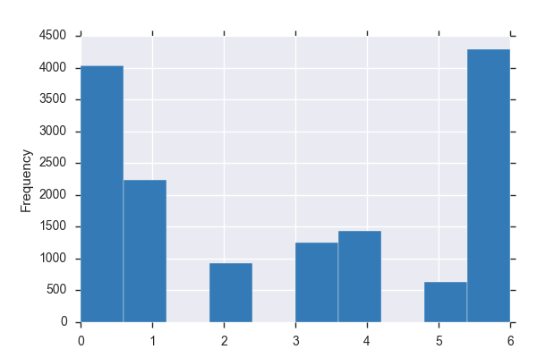

PARENT  
Categorical

| Distinct count | 5 |
| --- | --- |
| Unique (%) | 0.0% |
| Missing (%) | 0.0% |
| Missing (n) | 0 |

| Not_in_universe | 12619 |
| --- | --- |
| Bothparentspresent | 1508 |
| Motheronlypresent | 547 |
| Other values (2) | 126 |

Toggle details

| Value | Count | Frequency (%) |  |
| --- | --- | --- | --- |
| Not_in_universe | 12619 | 85.3% |  |
| Bothparentspresent | 1508 | 10.2% |  |
| Motheronlypresent | 547 | 3.7% |  |
| Fatheronlypresent | 63 | 0.4% |  |
| Neitherparentpresent | 63 | 0.4% |  |

PEFNTVTY  
Categorical

| Distinct count | 40 |
| --- | --- |
| Unique (%) | 0.3% |
| Missing (%) | 0.0% |
| Missing (n) | 0 |

| United-States | 12634 |
| --- | --- |
| Mexico | 444 |
| Italy | 175 |
| Other values (37) | 1547 |

Toggle details

| Value | Count | Frequency (%) |  |
| --- | --- | --- | --- |
| United-States | 12634 | 85.4% |  |
| Mexico | 444 | 3.0% |  |
| Italy | 175 | 1.2% |  |
| Puerto-Rico | 140 | 0.9% |  |
| Canada | 122 | 0.8% |  |
| Germany | 121 | 0.8% |  |
| Poland | 111 | 0.8% |  |
| Philippines | 85 | 0.6% |  |
| England | 84 | 0.6% |  |
| Cuba | 77 | 0.5% |  |
| China | 72 | 0.5% |  |
| Ireland | 66 | 0.4% |  |
| Dominican-Republic | 63 | 0.4% |  |
| India | 60 | 0.4% |  |
| El-Salvador | 51 | 0.3% |  |
| SouthKorea | 47 | 0.3% |  |
| Greece | 38 | 0.3% |  |
| Hungary | 35 | 0.2% |  |
| Japan | 33 | 0.2% |  |
| Columbia | 28 | 0.2% |  |
| Other values (20) | 314 | 2.1% |  |

PEMNTVTY  
Categorical

| Distinct count | 40 |
| --- | --- |
| Unique (%) | 0.3% |
| Missing (%) | 0.0% |
| Missing (n) | 0 |

| United-States | 12709 |
| --- | --- |
| Mexico | 455 |
| Canada | 129 |
| Other values (37) | 1507 |

Toggle details

| Value | Count | Frequency (%) |  |
| --- | --- | --- | --- |
| United-States | 12709 | 85.9% |  |
| Mexico | 455 | 3.1% |  |
| Canada | 129 | 0.9% |  |
| Puerto-Rico | 128 | 0.9% |  |
| Germany | 123 | 0.8% |  |
| Italy | 117 | 0.8% |  |
| Poland | 91 | 0.6% |  |
| England | 88 | 0.6% |  |
| Philippines | 85 | 0.6% |  |
| Ireland | 75 | 0.5% |  |
| Cuba | 73 | 0.5% |  |
| El-Salvador | 69 | 0.5% |  |
| China | 63 | 0.4% |  |
| India | 61 | 0.4% |  |
| SouthKorea | 49 | 0.3% |  |
| Dominican-Republic | 49 | 0.3% |  |
| Japan | 39 | 0.3% |  |
| Hungary | 31 | 0.2% |  |
| Columbia | 31 | 0.2% |  |
| Taiwan | 28 | 0.2% |  |
| Other values (20) | 307 | 2.1% |  |

PENATVTY  
Categorical

| Distinct count | 40 |
| --- | --- |
| Unique (%) | 0.3% |
| Missing (%) | 0.0% |
| Missing (n) | 0 |

| United-States | 13537 |
| --- | --- |
| Mexico | 275 |
| Germany | 82 |
| Other values (37) | 906 |

Toggle details

| Value | Count | Frequency (%) |  |
| --- | --- | --- | --- |
| United-States | 13537 | 91.5% |  |
| Mexico | 275 | 1.9% |  |
| Germany | 82 | 0.6% |  |
| Philippines | 74 | 0.5% |  |
| Puerto-Rico | 69 | 0.5% |  |
| Cuba | 60 | 0.4% |  |
| Canada | 59 | 0.4% |  |
| India | 54 | 0.4% |  |
| SouthKorea | 47 | 0.3% |  |
| England | 44 | 0.3% |  |
| Italy | 38 | 0.3% |  |
| El-Salvador | 38 | 0.3% |  |
| China | 37 | 0.2% |  |
| Japan | 32 | 0.2% |  |
| Dominican-Republic | 32 | 0.2% |  |
| Taiwan | 28 | 0.2% |  |
| Poland | 27 | 0.2% |  |
| Columbia | 24 | 0.2% |  |
| Greece | 20 | 0.1% |  |
| Guatemala | 18 | 0.1% |  |
| Other values (20) | 205 | 1.4% |  |

PRCITSHP  
Categorical

| Distinct count | 5 |
| --- | --- |
| Unique (%) | 0.0% |
| Missing (%) | 0.0% |
| Missing (n) | 0 |

| Native-BornintheUnitedStates | 13537 |
| --- | --- |
| Foreignborn-NotacitizenofUS | 627 |
| Foreignborn-UScitizenbynaturalization | 449 |
| Other values (2) | 187 |

Toggle details

| Value | Count | Frequency (%) |  |
| --- | --- | --- | --- |
| Native-BornintheUnitedStates | 13537 | 91.5% |  |
| Foreignborn-NotacitizenofUS | 627 | 4.2% |  |
| Foreignborn-UScitizenbynaturalization | 449 | 3.0% |  |
| Native-BornabroadofAmericanParent(s) | 115 | 0.8% |  |
| Native-BorninPuertoRicoorUSOutlying | 72 | 0.5% |  |

SEOTR  
Numeric

| Distinct count | 3 |
| --- | --- |
| Unique (%) | 0.0% |
| Missing (%) | 0.0% |
| Missing (n) | 0 |
| Infinite (%) | 0.0% |
| Infinite (n) | 0 |

| Mean | 0.21155 |
| --- | --- |
| Minimum | 0 |
| Maximum | 2 |
| Zeros (%) | 88.1% |

Toggle details

Quantile statistics

| Minimum | 0 |
| --- | --- |
| 5-th percentile | 0 |
| Q1 | 0 |
| Median | 0 |
| Q3 | 0 |
| 95-th percentile | 2 |
| Maximum | 2 |
| Range | 2 |
| Interquartile range | 0 |

Descriptive statistics

| Standard deviation | 0.59246 |
| --- | --- |
| Coef of variation | 2.8005 |
| Kurtosis | 4.7503 |
| Mean | 0.21155 |
| MAD | 0.37256 |
| Skewness | 2.5582 |
| Sum | 3131 |
| Variance | 0.35101 |
| Memory size | 115.7 KiB |

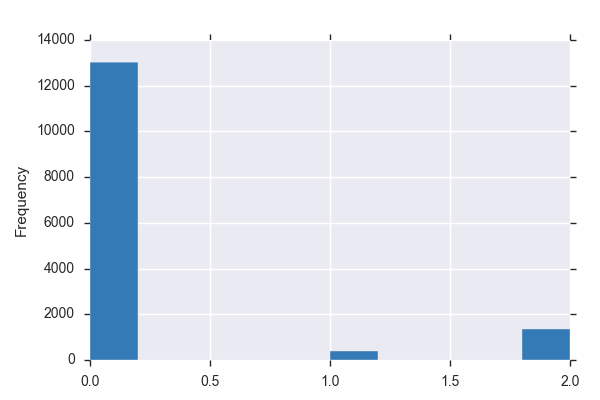

TAXINC  
Categorical

| Distinct count | 3 |
| --- | --- |
| Unique (%) | 0.0% |
| Missing (%) | 0.0% |
| Missing (n) | 0 |

| Not_in_universe | 14590 |
| --- | --- |
| No | 189 |
| Yes | 21 |

Toggle details

| Value | Count | Frequency (%) |  |
| --- | --- | --- | --- |
| Not_in_universe | 14590 | 98.6% |  |
| No | 189 | 1.3% |  |
| Yes | 21 | 0.1% |  |

VETQVA  
Numeric

| Distinct count | 3 |
| --- | --- |
| Unique (%) | 0.0% |
| Missing (%) | 0.0% |
| Missing (n) | 0 |
| Infinite (%) | 0.0% |
| Infinite (n) | 0 |

| Mean | 1.7332 |
| --- | --- |
| Minimum | 0 |
| Maximum | 2 |
| Zeros (%) | 12.6% |

Toggle details

Quantile statistics

| Minimum | 0 |
| --- | --- |
| 5-th percentile | 0 |
| Q1 | 2 |
| Median | 2 |
| Q3 | 2 |
| 95-th percentile | 2 |
| Maximum | 2 |
| Range | 2 |
| Interquartile range | 0 |

Descriptive statistics

| Standard deviation | 0.66947 |
| --- | --- |
| Coef of variation | 0.38626 |
| Kurtosis | 2.7177 |
| Mean | 1.7332 |
| MAD | 0.45857 |
| Skewness | -2.1561 |
| Sum | 25652 |
| Variance | 0.4482 |
| Memory size | 115.7 KiB |

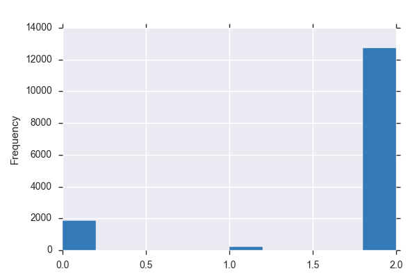

VETYN  
Numeric

| Distinct count | 51 |
| --- | --- |
| Unique (%) | 0.3% |
| Missing (%) | 0.0% |
| Missing (n) | 0 |
| Infinite (%) | 0.0% |
| Infinite (n) | 0 |

| Mean | 35.101 |
| --- | --- |
| Minimum | 0 |
| Maximum | 52 |
| Zeros (%) | 27.2% |

Toggle details

Quantile statistics

| Minimum | 0 |
| --- | --- |
| 5-th percentile | 0 |
| Q1 | 0 |
| Median | 52 |
| Q3 | 52 |
| 95-th percentile | 52 |
| Maximum | 52 |
| Range | 52 |
| Interquartile range | 52 |

Descriptive statistics

| Standard deviation | 23.161 |
| --- | --- |
| Coef of variation | 0.65984 |
| Kurtosis | -1.3332 |
| Mean | 35.101 |
| MAD | 21.304 |
| Skewness | -0.76008 |
| Sum | 519495 |
| Variance | 536.44 |
| Memory size | 115.7 KiB |

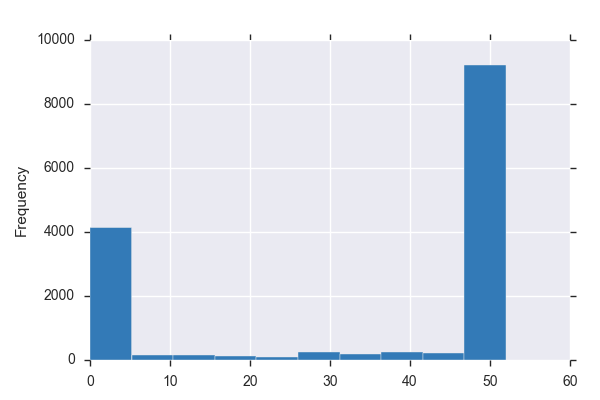

Constant

*This variable is constant and should be ignored for analysis*

| Constant value | 94 |
| --- | --- |

index  
Numeric

| Distinct count | 10000 |
| --- | --- |
| Unique (%) | 67.6% |
| Missing (%) | 0.0% |
| Missing (n) | 0 |
| Infinite (%) | 0.0% |
| Infinite (n) | 0 |

| Mean | 4156.3 |
| --- | --- |
| Minimum | 0 |
| Maximum | 9999 |
| Zeros (%) | 0.0% |

Toggle details

Quantile statistics

| Minimum | 0 |
| --- | --- |
| 5-th percentile | 369.95 |
| Q1 | 1849.8 |
| Median | 3699.5 |
| Q3 | 6299.2 |
| 95-th percentile | 9259 |
| Maximum | 9999 |
| Range | 9999 |
| Interquartile range | 4449.5 |

Descriptive statistics

| Standard deviation | 2781.2 |
| --- | --- |
| Coef of variation | 0.66917 |
| Kurtosis | -0.90055 |
| Mean | 4156.3 |
| MAD | 2334.9 |
| Skewness | 0.44674 |
| Sum | 61512600 |
| Variance | 7735200 |
| Memory size | 115.7 KiB |

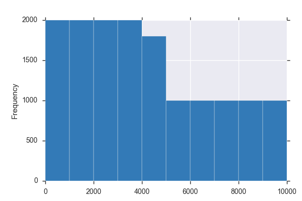

# Sample

|  | AAGE | ACLSWKR | ADTIND | ADTOCC | AHGA | AHRSPAY | AHSCOL | AMARITL | AMJIND | AMJOCC | ARACE | AREORGN | ASEX | AUNMEM | AUNTYPE | AWKSTAT | CAPGAIN | CAPLOSS | DIVVAL | FILESTAT | GRINREG | GRINST | HHDFMX | HHDREL | MARSUPWT | MIGMTR1 | MIGMTR3 | MIGMTR4 | MIGSAME | … |
| --- | --- | --- | --- | --- | --- | --- | --- | --- | --- | --- | --- | --- | --- | --- | --- | --- | --- | --- | --- | --- | --- | --- | --- | --- | --- | --- | --- | --- | --- | --- |
| 0 | 43 | LocalGovernment | 43 | 10 | Mastersdegree(MAMSMEngMEdMSWMBA) | 0 | Not_in_universe | Married-civilianspousepresent | Education | Professionalspecialty | White | Allother | Female | Not_in_universe | Not_in_universe | ChildrenorArmedForces | 0 | 0 | 2 | Jointbothunder65 | Not_in_universe | Not_in_universe | Spouseofhouseholder | Spouseofhouseholder | 1232.40 | Nonmover | Nonmover | Nonmover | Yes | … |
| 1 | 0 | Not_in_universe | 0 | 0 | Children | 0 | Not_in_universe | Nevermarried | Not_in_universeorchildren | Not_in_universe | White | Allother | Male | Not_in_universe | Not_in_universe | ChildrenorArmedForces | 0 | 0 | 0 | Nonfiler | Not_in_universe | Not_in_universe | Child<18nevermarrnotinsubfamily | Childunder18nevermarried | 3062.92 | Not_in_universe | Not_in_universe | Not_in_universe | Not_in_universeunder1yearold | … |
| 2 | 44 | Private | 11 | 22 | Somecollegebutnodegree | 0 | Not_in_universe | Married-civilianspousepresent | Manufacturing-durablegoods | Admsupportincludingclerical | White | Allother | Female | Not_in_universe | Not_in_universe | ChildrenorArmedForces | 0 | 0 | 1000 | Jointbothunder65 | Not_in_universe | Not_in_universe | Spouseofhouseholder | Spouseofhouseholder | 1502.40 | Nonmover | Nonmover | Nonmover | Yes | … |
| 3 | 43 | Self-employed-incorporated | 35 | 17 | Bachelorsdegree(BAABBS) | 0 | Not_in_universe | Married-civilianspousepresent | Financeinsuranceandrealestate | Sales | White | Allother | Male | Not_in_universe | Not_in_universe | ChildrenorArmedForces | 99999 | 0 | 1000 | Jointbothunder65 | Not_in_universe | Not_in_universe | Householder | Householder | 295.30 | Nonmover | Nonmover | Nonmover | Yes | … |
| 4 | 39 | Private | 24 | 26 | Bachelorsdegree(BAABBS) | 0 | Not_in_universe | Married-civilianspousepresent | Manufacturing-nondurablegoods | Admsupportincludingclerical | White | Allother | Male | Not_in_universe | Not_in_universe | ChildrenorArmedForces | 0 | 0 | 0 | Jointbothunder65 | Not_in_universe | Not_in_universe | Householder | Householder | 2700.08 | Nonmover | Nonmover | Nonmover | Yes | … |